# STAT340: Discussion 7: Earthquake Estimation

Steven Hizmi

10 March, 2021

Link to source file

## Just for fun (1 min)

[figure not shown]

## Discuss together (≤ 5 min)

As an entire section, discuss these together:

1. Are your estimates of the parameters of a model random or fixed? Why?
2. What does it mean to find a confidence interval for an estimate? Explain in the context of conducting the same experiment many times.

## Exercise

Today’s exercise is intended to be a gentle introduction/review of estimation. We will be using **real data** from the [US Geological Survey (USGS)](https://www.usgs.gov/natural-hazards/earthquake-hazards/earthquakes) to build a model to **estimate the frequency of earthquakes** across the world.

As usual, break off into **groups of 3-4 students**. In your group, nominate one person to share their screen.

### Background

In seismology (the study of earthquakes), the relationship between the frequency and magnitude of earthquakes (in a certain place and period of time) can be modeled by the [Gutenberg-Richter law](https://en.wikipedia.org/wiki/Gutenberg%E2%80%93Richter_law) (GR law). Let $M$ be the [Richter magnitude](https://en.wikipedia.org/wiki/Richter_magnitude_scale) of a seismic event, and $N$ be the number of events with magnitude **greater than or equal to $M$**. Then, the GR law states that
$$N=10^{a-bM}$$
or in other words
$$\log_{10}(N)=a-bM$$
where $a$ and $b$ are unknown constants that depend on the particular choice of place/period. Note that this relationship should appear as a line on a plot of $\log_{10}(N)$ vs $M$.

### Data import

This dataset contains every earthquake (on Earth, not just in the US) of magnitude 4.5 or greater that was detected by USGS from beginning of 2017 to end of 2020. A detailed description of the columns can be [**found here**](https://earthquake.usgs.gov/data/comcat/data-eventterms.php), but the **main variables** we are interested in **are `time` and `mag.binned`** (magnitude rounded to nearest half integer).

For convenience, much of the data cleaning and preprocessing has already been done for you; **download the prepared data here** and **save into the same directory as this source file**. Then, uncomment and run the lines of code below to import the data.

```r
library(tidyverse)

parseTime = function(times){
  return(as.POSIXct(strptime(times,"%Y-%m-w%d %H:%M:%OS",tz="UTC")))
}

quakes = read.csv("quakes.csv.gz") %>%
  mutate_at(c("time","updated"),parseTime)


# EXPLANATION:
# parseTime here is a function to help convert the datetime strings in this file to datetime format
# mutate_at is used to apply parseTime to both the "time" and "updated" columns
# also, recall that .gz means it's been compressed using the gz program, which saves a lot of space,
#   but R can still directly read it as if it's an ordinary csv file (underrated feature)
```

For our purposes, this data needs to be summarized to obtain $N$ vs $M$ values for each year, where $N$ is the number of earthquakes with magnitude at least as strong as a given value of $M$ (see wiki page on [GR law](https://en.wikipedia.org/wiki/Gutenberg%E2%80%93Richter_law) for more details). Since this is a bit tricky, it’s also been done for you below.

```r
quakes.count = quakes %>%
  count(year,mag.binned,name='count') %>%
  group_by(year) %>%
  mutate(N = rev(cumsum(rev(count))), year=as.factor(year))


# EXPLANATION:
# count(year,mag.binned) counts how many events with that magnitude occurred each year
#   (see https://dplyr.tidyverse.org/reference/count.html for more info)
#
# group_by(year) followed by cumsum(...) takes the cumulative sum in each year
# the rev(...rev(...)) runs this cumsum in reverse (otherwise we get ≤M instead of ≥M)
#
# we also change year to factor for use in ggplot later
#   (aesthetics like group, color, shape, etc. often need a factor to work properly)
```

Before moving onto the next step, inspect the data frame to **make sure you completely understand what it represents** and check that everything looks right. (Your first and last rows should look something like `2017, 4.5, 6847, 9472` and `2020, 7.0, 10, 10`).

```r
head(quakes.count,10)
```

```
 # # A tibble: 10 x 4
 # # Groups:   year [2]
 #    year  mag.binned count     N
 #    <fct>      <dbl> <int> <int>
 #  1 2017         4.5  6847  9472
 #  2 2017         5    2018  2625
 #  3 2017         5.5   447   607
 #  4 2017         6     111   160
 #  5 2017         6.5    41    49
 #  6 2017         7       8     8
 #  7 2018         4.5  8041 11077
 #  8 2018         5    2297  3036
 #  9 2018         5.5   527   739
 # 10 2018         6     150   212
```

### Visualization

As usual, the **first step is to visualize the data**. Make a **scatter plot** of $\log_{10}(N)$ vs $M$ (note this means $M$ is on the horizontal axis (you say $y$ vs $x$, NOT $x$ vs $y$)). Then, **add a line plot on top**, making sure the **years are correctly grouped** together and distinguished from each other (use something like `color` or `shape` or even `linetype`, or a combination of them, (use your judgment to determine what looks best)).

*Note: you can either use `log10(N)` as the `y` aesthetic, OR directly use `y=N` and just rescale the axis to be logarithmic using `scale_y_log10()`. I recommend this second method since it makes the axis easier to read ([see here for an example](https://stackoverflow.com/a/9223257)).*

Ideally, it might look something like this (don’t forget to add nice title/labels!)

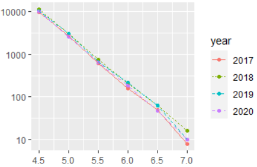

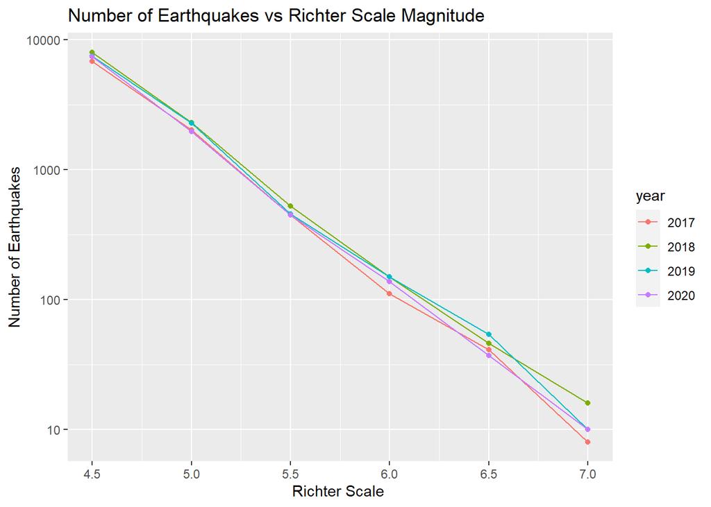

```r
 ggplot(quakes.count,aes(x = mag.binned, y=count, color=year)) +
  scale_y_log10() +
  geom_line() +
  geom_point() +
  xlab("Richter Scale ") + ylab("Number of Earthquakes") +
  ggtitle("Number of Earthquakes vs Richter Scale Magnitude")
```

### Estimation

Next, we will fit a simple linear regression to the data to estimate $a$ and $b$. Complete the line of code below to fit the model (don’t forget the linear relationship is NOT between $N$ and $M$ but rather between $\log_{10}(N)$ and $M$, so adjust your model formula accordingly!).

```r
 lm.quakes = lm(log10(count)~mag.binned, quakes.count)
```

View a summary of the model to see coefficients’ estimates, $p$-values, and other relevant info.

```r
 summary(lm.quakes)
```

```
 #
 # Call:
 # lm(formula = log10(count) ~ mag.binned, data = quakes.count)
 #
 # Residuals:
 #      Min       1Q   Median       3Q      Max
 # -0.12737 -0.03046  0.00416  0.02286  0.17366
 #
 # Coefficients:
 #             Estimate Std. Error t value Pr(>|t|)
 # (Intercept)  8.95866    0.10071   88.95   <2e-16 ***
 # mag.binned  -1.13260    0.01732  -65.37   <2e-16 ***
 # ---
 # Signif. codes:  0 '***' 0.001 '**' 0.01 '*' 0.05 '.' 0.1 ' ' 1
 #
 # Residual standard error: 0.07248 on 22 degrees of freedom
 # Multiple R-squared:  0.9949, Adjusted R-squared:  0.9946
 # F-statistic:  4274 on 1 and 22 DF,  p-value: < 2.2e-16
```

From your fit, what are your estimates for the constants $a$ and $b$? Pay **careful attention** to the signs here! (hint: remember the GR law uses the convention $a-bM$ whereas R assumes you are fitting `intercept + slope * M`, so therefore your fitted `slope` = $-b$).

Try to avoid copy-pasting or manually typing in values. The `coef()` function lets you extract coefficients from a model object (e.g. `lm.quakes`). You can then use `[i]` to access the i-th value of this coefficients vector. You may also want to use `unname()` at the end to remove the name from the value (if you don’t, it may carry through later calculations and no longer be a correct name for the output value).

```r
 a = unname(coef(lm.quakes)[1])
 b = -unname(coef(lm.quakes)[2])
 a+b
```

```
 # [1] 10.09126
```

### Checking fit

It’s always **nice to visually check your fit** to make sure everything looks right. Plot your **line of best fit along with the data points** in the chunk below.

*Hint: this time, I recommend using `log10(N)` as the `y` aesthetic, then using [`geom_abline()`](https://ggplot2.tidyverse.org/reference/geom_abline.html) to plot your line of regression using your estimated slope and intercept values (this avoids dealing with distorted axis cause by the other method’s `scale_y_log10()` which can be non-intuitive to deal with). Note you can use your variables `a` and `b` here that were defined previously to avoid manually typing in numerical estimates (which is almost always bad!).*

```
 # `geom_smooth()` using formula 'y ~ x'
```

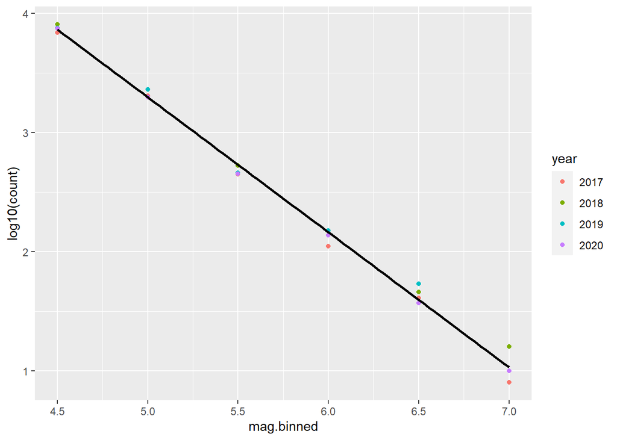

```r
 ggplot(quakes.count,aes(x=mag.binned, y=log10(count),color=year)) +
  geom_point() +
  geom_smooth(method = "lm", se = FALSE, color = "black")
```

You can also check [the residuals of your fit](https://rpubs.com/iabrady/residual-analysis). This is fairly convenient to do in base R. Note there is **slight heteroscedasticity** due to the fact that higher magnitude earthquakes occur much less often than lower magnitude earthquakes so it’s harder to estimate them as precisely. **This is expected** and not a huge threat to the validity of our model.

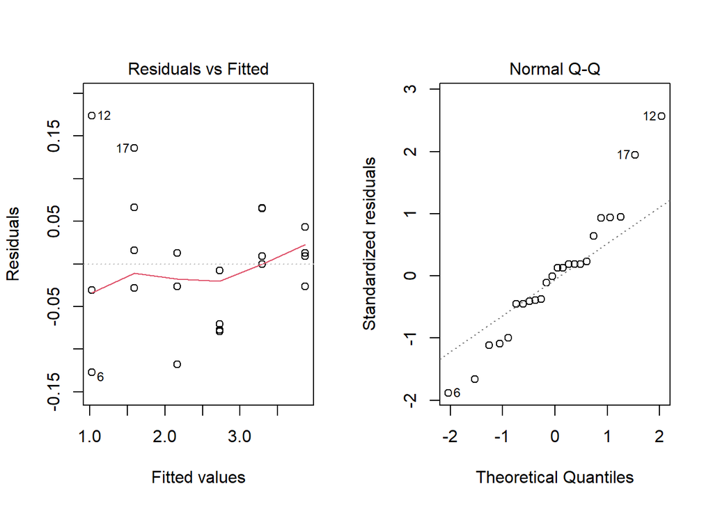

```r
 par(mfrow=c(1,2))
 plot(lm.quakes,which=1:2)
```

### Confidence

Give $99\%$ confidence intervals for $a$ and $b$ ([help page](https://www.rdocumentation.org/packages/stats/versions/3.6.2/topics/confint)).

```r
 a_est = confint(lm.quakes, level = 0.99)[3]
 b_est = -confint(lm.quakes, level = 0.99)[4]

 a_est
```

```
 # [1] 9.242541
```

```r
 b_est
```

```
 # [1] 1.083766
```

```r
 confint(lm.quakes, level=0.99)
```

```
 #                 0.5 %    99.5 %
 # (Intercept)  8.674785  9.242541
 # mag.binned  -1.181435 -1.083766
```

Give a brief interpretation of these intervals.

> **Because the confidence level is 99%, we can expect 99 out of 100 samples/interval estimates of earthquakes to contain a mean value between the confidence interval of [8.674, 9.2425].**

### Predictions

From the [GR law](https://en.wikipedia.org/wiki/Gutenberg%E2%80%93Richter_law#Background), we can deduce that the **total number of earthquakes of any magnitude** is equal to
$$N_\text{Total}=10^a$$
Using your estimate for $a$, **approximately** how many earthquakes are there in total every year on Earth? (Remember to think about how precisely you can estimate this and **round your answer appropriately!** Not all the digits you get from R are significant, so you only need some of them!).

Use the box below to compute your answer, then respond with a short sentence below.

```r
# perform calculations here
10 ** 9.2
```

```
 # [1] 1584893192
```

> **There is about 1.5 billion earthquakes every year on earth, which seems like a very large number at first. But the majority of earthquakes are lower on the richter scale, so we would not even notice a lot of them.**

Using your $99\%$ confidence interval for $a$, give an approximate $99\%$ confidence interval for $N_\text{Total}$.

```r
# perform calculations here
10 * a
```

```
 # [1] 89.58663
```

```r
10 ** a_est
```

```
 # [1] 1747996574
```

> **[89.58, 1747996574]**

According to your model, how many earthquakes of magnitude 7 or greater do you expect to see on average every year?

```r
# perform calculations here
10**(a_est - b_est*7)
```

```
 # [1] 45.30836
```

> **About 45 earthquakes a year that have a magnitude of 7 or higher**

According to your model, you would expect to see an earthquake with magnitude between 9 and 9.5 on average *once every how many years*?

```r
# perform calculations here
10**(a_est - b_est*9)
```

```
 # [1] 0.3080678
```

```r
10**(a_est - b_est*9.5)
```

```
 # [1] 0.08846332
```

> **We would see an earthquake with a magnitude of 9-9.5 every 3-11 years**

## Submission

As usual, make sure the **names of everyone** who worked on this with you is included in the header of this document. Then, **knit this document** and submit **both this file and the HTML output** on Canvas under Assignments ⇒ Discussion 7.